# 제목: ADP 실기를 위한 시계열 기초 정리

# 지문만 보고 1초 만에 파악하는 시계열 기초(Time Series Basics) 완벽 가이드

**시계열 분석(Time Series Analysis)**은 시간의 흐름에 따라 순서대로 관측된 데이터를 다루는 방법입니다. ADP 실기 시험에서는 일반적인 회귀나 분류 문제와 달리, **‘시간 순서 보존’**, **‘주기(frequency)’**, **‘추세/계절성 존재 여부’**를 먼저 점검해야 합니다.

## 🎯 [핵심] ADP 지문 키워드로 보는 시계열 기초 선택 가이드

문제를 읽고 아래의 키워드에 따라 어떤 준비를 먼저 해야 하는지 판단하세요.

| 확인 포인트 | 무엇을 봐야 하나? | ADP 지문 단골 키워드 (이렇게 문제에 나옵니다!) |
| --- | --- | --- |
| **시간 변수 확인** | 날짜형 변환, 정렬, 결측 시점 여부 | “**일별 매출 데이터**를 이용하여…” “**월별 수요량** 시계열을 분석하시오.” |
| **주기(frequency) 확인** | 계절 패턴의 반복 간격 | “**주기가 7인 시계열**”, “**월 단위 자료**”, “**분기별 데이터**” |
| **기초 패턴 확인** | 추세, 반복성, 변동 폭 | “시계열 그래프를 그리고 **패턴을 설명하시오**” “이동평균을 이용해 **추세를 파악하시오**” |

> 💡 **시계열 첫 반응 Tip:** * 날짜 컬럼이 보이면 -> **반드시 날짜형 변환 후 정렬** * “주기가 7” -> **일별 데이터 + 주간 계절성** 가능성 높음 * 바로 예측 모델로 가지 말고 -> **먼저 그래프와 기초 통계로 구조 파악**

시계열 문제는 처음부터 ARIMA 같은 모델을 쓰는 것이 아니라, **데이터가 시간에 따라 어떤 구조를 갖는지 기초 진단**하는 단계가 가장 중요합니다. 이 기초 단계가 흔들리면 뒤의 분해, 검정, 예측도 전부 꼬이게 됩니다.

## 1. 시계열 객체 만들기와 기본 시각화

시계열 분석의 출발점은 데이터를 날짜순으로 정렬하고, 적절한 주기를 지정해 시계열 객체로 변환하는 것입니다.

- **상황:** 한 온라인 쇼핑몰의 42일간 일별 매출(Sales) 데이터가 주어졌다. 이 데이터를 날짜순으로 정렬한 후 시계열 객체로 만들고, 기본 그래프를 통해 전반적인 흐름을 파악하시오.
- **핵심 포인트:**
  - 날짜형 변환이 필요하다.
  - 일별 데이터이며 주간 반복 가능성이 있으므로 `frequency = 7`을 고려할 수 있다.

### 🐍 Python 코드

```python
import pandas as pd
import matplotlib.pyplot as plt

# 1. GitHub Raw URL에서 데이터 불러오기
url = "https://raw.githubusercontent.com/MOON001208/ADP-data-set-and-analysis/main/adp_study/data/timeseries_basic_daily_sales.csv"
df = pd.read_csv(url)

# 2. 날짜형 변환 및 정렬
df['date'] = pd.to_datetime(df['date'])
df = df.sort_values('date')

print(df.head())

# 3. 기본 시계열 그래프
```

```
        date  sales
0 2025-01-01    120
1 2025-01-02    128
2 2025-01-03    133
3 2025-01-04    150
4 2025-01-05    158
```

```python
plt.figure(figsize=(10, 4))
plt.plot(df['date'], df['sales'], marker='o')
plt.title("Daily Sales Time Series")
plt.xlabel("Date")
plt.ylabel("Sales")
plt.xticks(rotation=45)
```

```
(array([20089., 20096., 20103., 20110., 20120., 20127.]), [Text(0, 0, ''), Text(0, 0, ''), Text(0, 0, ''), Text(0, 0, ''), Text(0, 0, ''), Text(0, 0, '')])
```

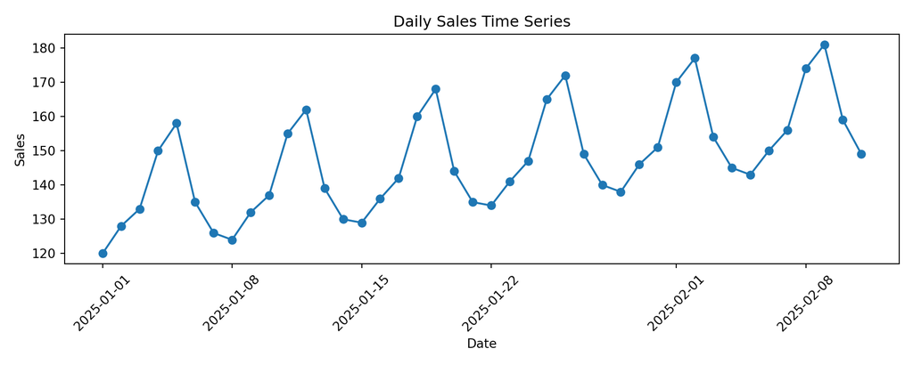

```python
plt.tight_layout()
plt.show()
```

### 📊 R 코드

```r
# 1. GitHub Raw URL에서 데이터 불러오기
url <- "https://raw.githubusercontent.com/MOON001208/ADP-data-set-and-analysis/main/adp_study/data/timeseries_basic_daily_sales.csv"
df <- read.csv(url)

# 2. 날짜형 변환 및 정렬
df$date <- as.Date(df$date)
df <- df[order(df$date), ]

head(df)
```

```
        date sales
1 2025-01-01   120
2 2025-01-02   128
3 2025-01-03   133
4 2025-01-04   150
5 2025-01-05   158
6 2025-01-06   135
```

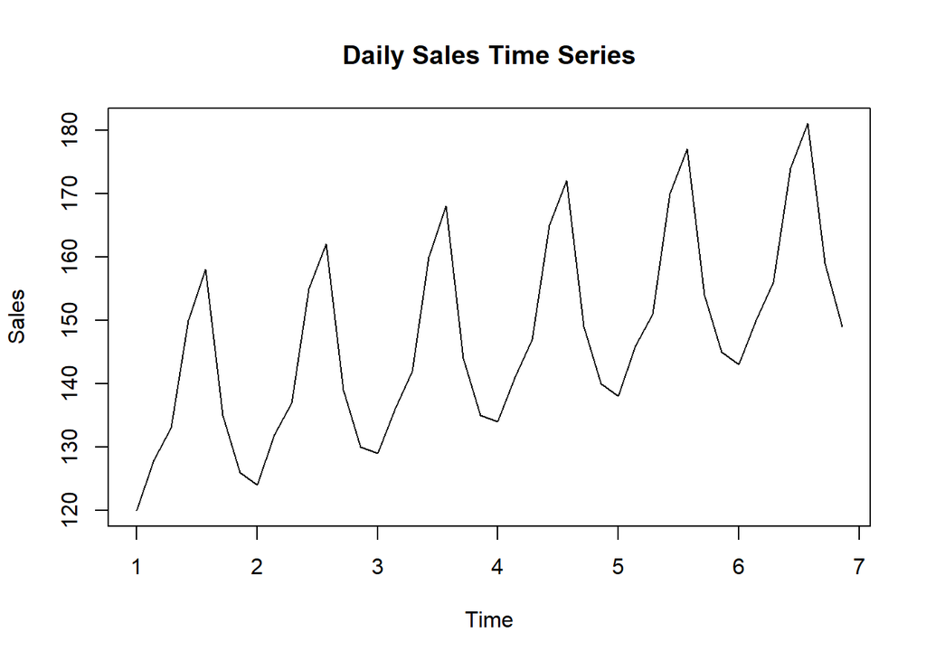

```r
# 3. 시계열 객체 생성 (주기 7 가정)
sales_ts <- ts(df$sales, frequency = 7)

# 4. 기본 시계열 그래프
plot(sales_ts, main = "Daily Sales Time Series", ylab = "Sales", xlab = "Time")
```

### 📝 [결론 해석 모범 답안 작성법]

> 일별 매출 데이터를 날짜형으로 변환한 뒤 시간순으로 정렬하고, 주기 7의 시계열 객체로 생성하였다. 시계열 그래프를 확인한 결과 전반적으로 매출이 점진적으로 증가하는 흐름이 관찰되며, 특정 간격으로 반복되는 파동도 함께 나타나므로 추세와 주기성이 동시에 존재할 가능성이 높다고 해석할 수 있다.

## 2. 이동평균과 롤링 통계로 추세 보기

원시 시계열은 변동이 커서 전체 흐름을 한눈에 보기 어려울 수 있습니다. 이때 **이동평균(Moving Average)**이나 **롤링 평균(Rolling Mean)**을 활용하면 부드러운 추세를 파악하기 쉽습니다.

- **상황:** 같은 매출 데이터에 대해 7일 이동평균을 계산하여 원시 시계열과 함께 비교하고, 매출 추세를 해석하시오.

### 🐍 Python 코드

```python
import pandas as pd
import matplotlib.pyplot as plt

# 1. GitHub Raw URL에서 데이터 불러오기
url = "https://raw.githubusercontent.com/MOON001208/ADP-data-set-and-analysis/main/adp_study/data/timeseries_basic_daily_sales.csv"
df = pd.read_csv(url)
df['date'] = pd.to_datetime(df['date'])
df = df.sort_values('date')

# 2. 7일 이동평균 계산
df['ma_7'] = df['sales'].rolling(window=7).mean()

print(df[['date', 'sales', 'ma_7']].tail())

# 3. 원시값과 이동평균 비교
```

```
         date  sales        ma_7
37 2025-02-07    156  156.428571
38 2025-02-08    174  157.000000
39 2025-02-09    181  157.571429
40 2025-02-10    159  158.285714
41 2025-02-11    149  158.857143
```

```python
plt.figure(figsize=(10, 4))
plt.plot(df['date'], df['sales'], label='Sales', alpha=0.6)
plt.plot(df['date'], df['ma_7'], label='7-day Moving Average', linewidth=2)
plt.title("Sales and 7-day Moving Average")
plt.xlabel("Date")
plt.ylabel("Sales")
plt.legend()
plt.xticks(rotation=45)
```

```
(array([20089., 20096., 20103., 20110., 20120., 20127.]), [Text(0, 0, ''), Text(0, 0, ''), Text(0, 0, ''), Text(0, 0, ''), Text(0, 0, ''), Text(0, 0, '')])
```

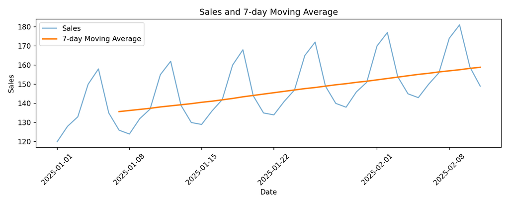

```python
plt.tight_layout()
plt.show()
```

### 📊 R 코드

```r
# 1. GitHub Raw URL에서 데이터 불러오기
url <- "https://raw.githubusercontent.com/MOON001208/ADP-data-set-and-analysis/main/adp_study/data/timeseries_basic_daily_sales.csv"
df <- read.csv(url)
df$date <- as.Date(df$date)
df <- df[order(df$date), ]

# 2. 7일 이동평균 계산
ma_7 <- stats::filter(df$sales, rep(1/7, 7), sides = 1)

tail(data.frame(date = df$date, sales = df$sales, ma_7 = ma_7))
```

```
         date sales     ma_7
37 2025-02-06   150 155.7143
38 2025-02-07   156 156.4286
39 2025-02-08   174 157.0000
40 2025-02-09   181 157.5714
41 2025-02-10   159 158.2857
42 2025-02-11   149 158.8571
```

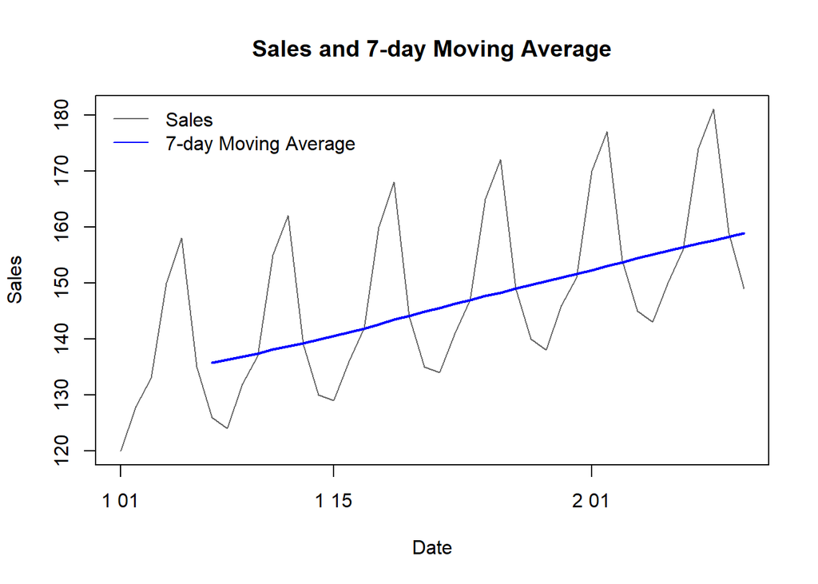

```r
# 3. 원시값과 이동평균 비교
plot(df$date, df$sales, type = "l", col = "gray40", lwd = 1,
     main = "Sales and 7-day Moving Average", xlab = "Date", ylab = "Sales")
lines(df$date, ma_7, col = "blue", lwd = 2)
legend("topleft", legend = c("Sales", "7-day Moving Average"),
       col = c("gray40", "blue"), lty = 1, bty = "n")
```

### 📝 [결론 해석 모범 답안 작성법]

> 7일 이동평균을 계산하여 원시 매출과 비교한 결과, 일별 변동을 완화한 상태에서도 매출이 전반적으로 상승하는 추세가 유지됨을 확인하였다. 따라서 단기적인 출렁임과 별개로 전체적인 매출 수준은 점차 증가하고 있다고 해석할 수 있다.

## 3. 주기(frequency)와 반복 패턴 이해하기

시계열 기초에서 가장 중요한 개념 중 하나가 **주기(frequency)**입니다. 예를 들어 일별 데이터에서 `frequency = 7`은 “7일마다 반복되는 계절성”을 의미할 수 있습니다.

- **상황:** 해당 매출 데이터는 주기가 7인 일별 시계열이라고 가정한다. 요일별 평균 매출을 계산하여 반복 패턴이 있는지 확인하시오.

### 🐍 Python 코드

```python
import pandas as pd

# 1. GitHub Raw URL에서 데이터 불러오기
url = "https://raw.githubusercontent.com/MOON001208/ADP-data-set-and-analysis/main/adp_study/data/timeseries_basic_daily_sales.csv"
df = pd.read_csv(url)
df['date'] = pd.to_datetime(df['date'])
df = df.sort_values('date')

# 2. 요일 변수 생성
df['weekday'] = df['date'].dt.day_name()

# 3. 요일별 평균 매출
weekday_order = ['Monday', 'Tuesday', 'Wednesday', 'Thursday', 'Friday', 'Saturday', 'Sunday']
weekday_mean = df.groupby('weekday')['sales'].mean().reindex(weekday_order)
print(weekday_mean)
```

```
weekday
Monday       146.666667
Tuesday      137.500000
Wednesday    131.333333
Thursday     138.833333
Friday       144.333333
Saturday     162.333333
Sunday       169.666667
Name: sales, dtype: float64
```

### 📊 R 코드

```r
# 1. GitHub Raw URL에서 데이터 불러오기
url <- "https://raw.githubusercontent.com/MOON001208/ADP-data-set-and-analysis/main/adp_study/data/timeseries_basic_daily_sales.csv"
df <- read.csv(url)
df$date <- as.Date(df$date)
df <- df[order(df$date), ]

# 2. 요일 변수 생성
df$weekday <- weekdays(df$date)

# 3. 요일별 평균 매출
aggregate(sales ~ weekday, data = df, mean)
```

```
  weekday    sales
1  금요일 144.3333
2  목요일 138.8333
3  수요일 131.3333
4  월요일 146.6667
5  일요일 169.6667
6  토요일 162.3333
7  화요일 137.5000
```

### 📝 [결론 해석 모범 답안 작성법]

> 요일별 평균 매출을 비교한 결과, 특정 요일에서 매출이 반복적으로 높고 다른 요일에서는 낮게 나타나는 패턴이 확인되었다. 따라서 이 데이터는 주기 7의 계절성을 가질 가능성이 높으며, 이후 시계열 분해나 예측 모형 구축 시 해당 주기 정보를 반영하는 것이 타당하다.

## ⛔ ADP 출제 위원회를 울리는 감점 방지 체크리스트

1. **“날짜형 변환 없이 바로 시계열 분석을 시작하면 안 됩니다.”**
   - 문자열 상태의 날짜는 시계열 순서를 제대로 반영하지 못할 수 있습니다.
   - 반드시 **날짜형 변환 -> 정렬** 순서로 전처리하세요.
2. **“frequency를 아무 숫자나 넣으면 안 됩니다.”**
   - `frequency = 7`은 보통 **일별 데이터의 주간 계절성**을 의미합니다.
   - 데이터 단위와 문제에서 제시한 주기를 연결해서 판단해야 합니다.
3. **“원시 그래프만 보고 끝내지 말고 이동평균도 같이 보세요.”**
   - 원시값은 노이즈가 커서 전체 흐름을 놓치기 쉽습니다.
   - 이동평균을 함께 보면 추세를 훨씬 안정적으로 파악할 수 있습니다.
4. **“시계열 문제는 처음부터 예측 모델로 들어가지 마세요.”**
   - 먼저 그래프, 주기, 추세, 변동성을 확인해야 합니다.
   - 이 기초 진단이 끝나야 분해, 검정, 예측이 자연스럽게 이어집니다.
5. **“주기성은 말로만 쓰지 말고 실제 반복 패턴을 보여주세요.”**
   - 요일별 평균이나 주기별 요약 통계를 같이 제시하면 해석이 훨씬 설득력 있어집니다.